# Coursework Report

*N* removed NAs: 6

*N* removed <18: 26

**Correct typo age:** 24

*N* total clean: 136

| Group | *N* | *M*<sub>age</sub> | % green |
| --- | --- | --- | --- |
| Control | 68 | 20.60 | 41.67 |
| Experim | 68 | 20.46 | 59.31 |

| Gender | *N* | *M*<sub>age</sub> | % green |
| --- | --- | --- | --- |
| Male | 61 | 20.57 | 50.27 |
| Female | 49 | 20.82 | 49.66 |
| Other | 26 | 19.88 | 52.56 |

**Main analysis results**

**car:**  
χ<sup>2</sup>(1) = 5.83, *p* = .016

**cleaner:**  
χ<sup>2</sup>(1) = 1.44, *p* = .230

**dishwasher:**  
χ<sup>2</sup>(1) = 4.28, *p* = .039

[interactive chart not shown]

[figure not shown]

[interactive chart not shown]

# Coursework Report

Analysing Data, Spring 2020

# Methods

## Participants

Table 1 *Descriptive statistics by experimental condition and gender*

| Experimental condition | Gender | N | % | M<sub>age</sub> | SD<sub>age</sub> | Min<sub>age</sub> | Max<sub>age</sub> |
| --- | --- | --- | --- | --- | --- | --- | --- |
| control | male | 29 | 21.32 | 20.62 | 1.76 | 18 | 24 |
| control | female | 29 | 21.32 | 20.97 | 2.29 | 18 | 26 |
| control | other | 10 | 7.35 | 19.50 | 1.83 | 18 | 23 |
| experimental | male | 32 | 23.53 | 20.53 | 2.01 | 18 | 25 |
| experimental | female | 20 | 14.71 | 20.60 | 1.44 | 18 | 24 |
| experimental | other | 16 | 11.76 | 20.12 | 1.67 | 18 | 24 |

## Design

This experiment aimed to investigate how eliciting status motives influenced the participant’s choices when selecting either the green version or the luxurious version of a product.

In order to test this, a between-subject design was used, in which participants were randomly assigned to one of two conditions: the experimental condition, or the control condition.

The independent variable was two short stories, and had two levels - one was designed to elicit status motives and was used for the experimental group, while the other elicited similar levels of affect but not status motives, and was used for the control group. Then, participants had to choose either a luxurious or green version for each of the three products (car, cleaner, and dishwasher).This acted as the dependent variable, and was recorded in the analysis as a factor variable. Their choices were then collated and recorded.

The proposed operational hypothesis is that the elicitation of status motives would increase the desire to purchase the green version of a product compared to the luxurious counterpart. In order to test this hypothesis, a chi squared analysis will be conducted in order to investigate whether there is a significant association between the activation of status motives in the experimental condition, and their choice of the green version over the luxury version of the products.

# Results

In the absence of activating status motives, it was predicted that participants would select the higher quality product over the green products. This is shown in the pattern of results, with participants in the control condition more likely to select the nongreen car (33.09%) over the green car (16.91%), and the nongreen dishwasher (27.21%) over the green dishwasher (22.79%).

Three chi-square analyses were performed to examine whether the choice of a green product was significantly associated with the elicitation of status motives in the experimental condition for each of the three products (car, cleaner, dishwasher). The choice of the green car increased from 16.91% in the control to 27.94% in the experimental condition, *χ*<sup>2</sup>(1) = 5.83, *p* < .016.This difference was found to be statistically significant. The participant’s choice of the green dishwasher also saw an increase, rising from 22.79% in the control condition to 32.35% in the experimental condition, *χ*<sup>2</sup>(1) = 4.28, *p* < .039. This difference was also significant. However, although there was an increase in the choice of the green cleaner between the control (22.79%) and the experimental condition (28.68%), this difference was not found to be significant, *χ*<sup>2</sup>(1) = 1.44, *p* < .230.

These results are represented in graph 1.

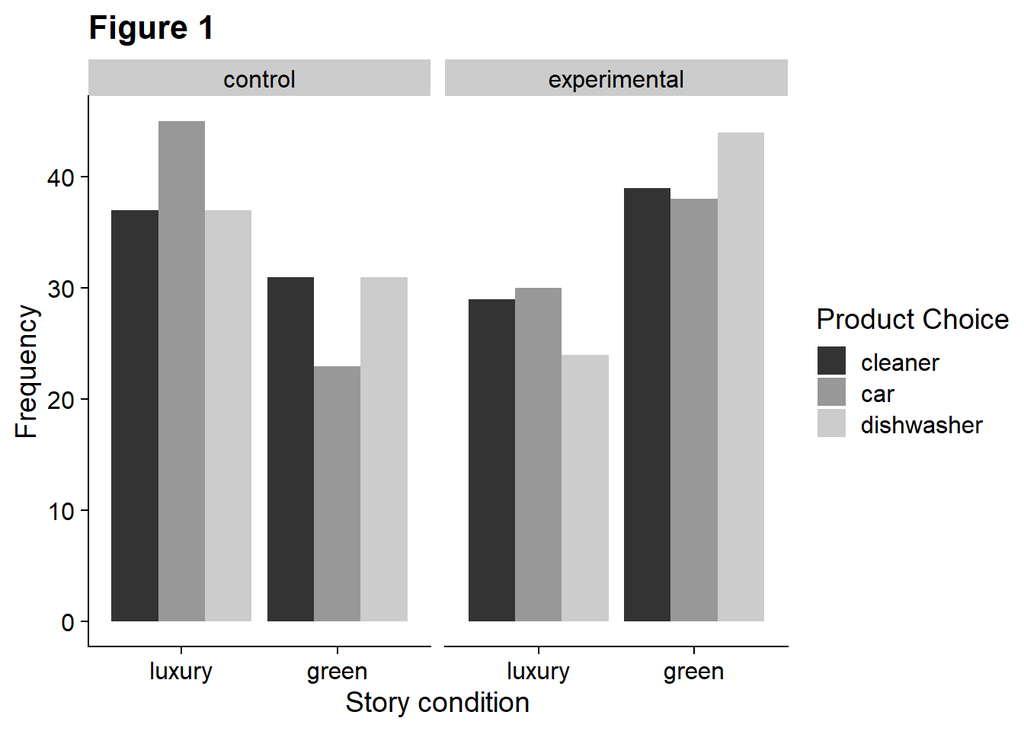

# Discussion

## Results and implications

This study aimed to replicate the first study of Griskevicius et al. (2010), using the costly signalling theory and competitive altruism to explain a potential link between status priming and altruistic acts – in this instance, the choice of an environmentally-friendly product over the conventional, more luxurious counterpart.

Studies that have investigated the costly signalling theory and competitive altruism have found compelling evidence for the link between status and altruistic acts, especially when purchases are public and conspicuous (Hardy & Van Vugt, 2006), and that these conspicuous displays of consumption can serve to signal the individual’s capability as a potential mate (Sundie et al., 2011). Using previous research as a basis, we would expect to find significant associations for all three of the products. However, conspicuous consumption can be used to explain why no significant association was found for the cleaner product.

The discrepancy in results between the products has important implications for competitive altruism. If this theory is applicable under these circumstances, then a significant difference can be expected for the cleaner product; the activation of status primes should increase the likelihood of individuals purchasing the green version, as it shows they are willing to incur the cost of a less luxurious product in order to be perceived as altruistic through benefiting the environment. However, this is not observed. Instead, conspicuous consumption may provide a valid explanation for this. Although the study didn’t directly test for conspicuous consumption, as the participants were not given the opportunity to select their products in a public environment, evidence for it can be inferred from, and explain, the results. Compared to the car and dishwasher, the cleaner is a relatively inconspicuous product. Participants may be less likely to buy the green version of a product if they could not successfully signal their purchase to the public. This is addressed Sexton and Sexton (2014), who proposed that people may be less likely to buy environmentally-friendly products if they are relatively inconspicuous, and used the example of the purchase of solar power over improvements in home insulation. Although both of these products are environmentally friendly and incur a cost to the individual, individuals are more likely to purchase the more conspicuous product.

Another potential explanation for the discrepancy in results may be differences in cultural values. Griskevicius’ original study was based in America, while this replication study was conducted in England; therefore, cultural differences may have influenced consumer choice. De Silva et al. (2020) found that the consumption values of individuals differ between cultures, and this in turn influenced the likelihood of purchasing environmentally friendly products. Therefore, cultural differences may have been a factor in the type of product that people are willing to buy with the activation of status motives.

Although the study didn’t manipulate the price of the product, evidence for competitive altruism can be observed in participants who were willing to incur the cost of a less luxurious product. The purchase of a conspicuous, inferior product allows the individuals to successfully advertise their wealth and ability to incur such costs.

This study has important practical implications. Increasing private green consumerism is possible by activating status primes to increase the likelihood of choosing environmentally-friendly products over the conventional version. Furthermore, by ensuring the products are conspicuous, individuals are able to advertise their purchase of a costly product, as suggested by competitive altruism. This is one potential of increasing private green consumerism, and is particularly applicable to countries with high CO2 emissions. In particular, the purchase of a green car over a conventional car would significantly reduce carbon emissions. The application of conspicuous consumption to increase green product sales has much potential.

However, research has shown that although conspicuous consumption and status consumption are related, they remain distinct constructs (O’Cass & McEwen, 2004). This is important because this study does not seek to separate them, and concludes that conspicuous consumption is driven by status motives, increasing the likelihood of selecting green products.

## Limitations and areas of potential research

This study did not test for either price or conspicuousness of the product. Therefore, this does not directly test for either conspicuous consumption or competitive altruism, and evidence for this has to be inferred indirectly from the pattern of results. The results partially support our hypothesis, but offers no insight into why it occurs. Furthermore, the study is limited by the small age range, which limits the external validity of the study; the sample does not generalise well.

However, the main limitation of this study is that it only investigated the intent to purchase environmentally-friendly products, instead of how this intent may be acted on in a practical setting. There remains the possibility that intentions and behaviours are distinctly removed from each other. Research conducted into this has suggested that intentions can be poor predictors of future consumerism (Chandon et al., 2005). Therefore, future research should implement the exchange of money for a real cost to be incurred.

Another potential direction for future research is investigating how different traits can lead to more green consumerism, by addressing how individual differences may influence people’s susceptibility to status priming, and how likely they are to purchase green products. Some research has shown that the personality traits of agreeableness, conscientiousness and openness-to-experience are positively related to proenvironmental behaviour (Milfont & Sibley, 2012). This can relate to the findings of this study by identifying how personal differences can affect individual’s responses to status priming.

Finally, there is scope to conduct this research in different cultures, as both this replication and Griskevicius’ work takes place in western civilisations. Western society views proenvironmental behaviour – such as the purchase of green products – as prosocial, but this may be interpreted differently elsewhere. Therefore, external validity can be established by repeating this study in different cultures – for example, cultures with a more collectivist mindset than an individualistic one, or a country that struggles with green consumerism, such as China.

# Conclusion

This study attempted to replicate the study by Griskevicius et al. (2010), and observed a slightly different pattern of results than expected. Although significant associations were observed for the products of car and dishwasher, there was no significant association found for the cleaner product. Therefore, status motives do not always increase the likelihood of purchasing green products. Some of the literature surrounding this topic has focused on conspicuous consumption, which may provide a way to explain these results. However, additional research should be conducted to clarify the link between intentions and future consumerism, and address potential cross-culteral differences.

# References

Griskevicius, V., Tybur, J., & Van den Bergh, B. (2010). Going green to be seen: Status, reputation, and conspicuous conservation. Journal Of Personality And Social Psychology, 98(3), 392-404. https://doi.org/10.1037/a0017346

Hardy, C., & Van Vugt, M. (2006). Nice Guys Finish First: The Competitive Altruism Hypothesis. Personality And Social Psychology Bulletin, 32(10), 1402-1413. https://doi.org/10.1177/0146167206291006

Sundie, J., Kenrick, D., Griskevicius, V., Tybur, J., Vohs, K., & Beal, D. (2011). Peacocks, Porsches, and Thorstein Veblen: Conspicuous consumption as a sexual signaling system. Journal Of Personality And Social Psychology, 100(4), 664-680. https://doi.org/10.1037/a0021669

Sexton, S., & Sexton, A. (2014). Conspicuous conservation: The Prius halo and willingness to pay for environmental bona fides. Journal Of Environmental Economics And Management, 67(3), 303-317. https://doi.org/10.1016/j.jeem.2013.11.004

De Silva, M., Wang, P., & Kuah, A. (2020). Why wouldn’t green appeal drive purchase intention? Moderation effects of consumption values in the UK and China. Journal Of Business Research. https://doi.org/10.1016/j.jbusres.2020.01.016

O’Cass, A., & McEwen, H. (2004). Exploring consumer status and conspicuous consumption. Journal Of Consumer Behaviour, 4(1), 25-39. https://doi.org/10.1002/cb.155

Chandon, P., Morwitz, V., & Reinartz, W. (2005). Do Intentions Really Predict Behavior? Self-Generated Validity Effects in Survey Research. Journal Of Marketing, 69(2), 1-14. https://doi.org/10.1509/jmkg.69.2.1.60755

Milfont, T., & Sibley, C. (2012). The big five personality traits and environmental engagement: Associations at the individual and societal level. Journal Of Environmental Psychology, 32(2), 187-195. https://doi.org/10.1016/j.jenvp.2011.12.006

# Appendix

Table 1 *Results from control condition*

| Category | Product | Frequency | Percentage |
| --- | --- | --- | --- |
| luxury | cleaner | 37 | 27.21 |
| luxury | car | 45 | 33.09 |
| luxury | dishwasher | 37 | 27.21 |
| green | cleaner | 31 | 22.79 |
| green | car | 23 | 16.91 |
| green | dishwasher | 31 | 22.79 |

Table 2 *Results from experimental condition*

| Category | Product | Frequency | Percentage |
| --- | --- | --- | --- |
| luxury | cleaner | 29 | 21.32 |
| luxury | car | 30 | 22.06 |
| luxury | dishwasher | 24 | 17.65 |
| green | cleaner | 39 | 28.68 |
| green | car | 38 | 27.94 |
| green | dishwasher | 44 | 32.35 |

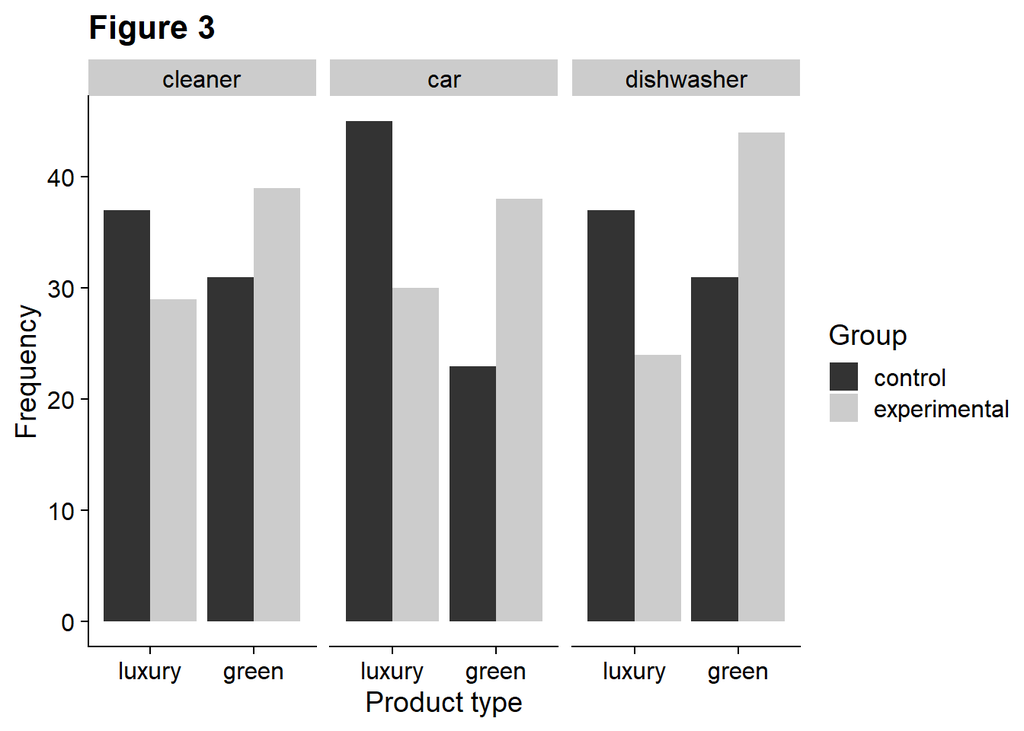